# Презентация по лабораторной работе №8

Текстовой редактор vi

Сагдеров Камал

Российский университет дружбы народов, Москва, Россия

26.03.23

## Цель работы

Познакомиться с операционной системой Linux. Получить практические навыки работы с редактором vi, установленным по умолчанию практически во всех дистрибутивах.

## Основные задачи

8.3.1. Задание 1. Создание нового файла с использованием vi 1. Создайте каталог с именем ~/work/os/lab06. 2. Перейдите во вновь созданный каталог. 3. Вызовите vi и создайте файл hello.sh 4. Нажмите клавишу i и вводите следующий текст 5. Нажмите клавишу Esc для перехода в командный режим после завершения вводатекста. 6. Нажмите : для перехода в режим последней строки и внизу вашего экрана появится приглашение в виде двоеточия.

## Основные задачи

7. Нажмите w (записать) и q (выйти), а затем нажмите клавишу Enter для сохранения вашего текста и завершения работы.
8. Сделайте файл исполняемым 8.3.2. Задание 2. Редактирование существующего файла
9. Вызовите vi на редактирование файл
10. Установите курсор в конец слова HELL второй строки.
11. Перейдите в режим вставки и замените на HELLO. Нажмите Esc для возврата в командный режим.
12. Установите курсор на четвертую строку и сотрите слово LOCAL.

## Основные задачи

5. Перейдите в режим вставки и наберите следующий текст: local, нажмите Esc для возврата в командный режим.
6. Установите курсор на последней строке файла. Вставьте после неё строку, содержащую следующий текст: echo $HELLO.
7. Нажмите Esc для перехода в командный режим.
8. Удалите последнюю строку.
9. Введите команду отмены изменений u для отмены последней команды.
10. Введите символ : для перехода в режим последней строки. Запишите произведённыеизменения и выйдите из vi

## Процесс выполнения

Ознакомимся с теоретическим материалом.Ознакомиться с редактором vi. Выполнить упражнения, используя команды vi

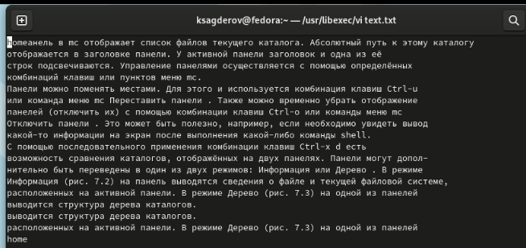

Текстовый редактор vi

## Процесс выполнения

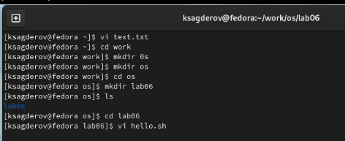

Создание каталога

## Процесс выполнения

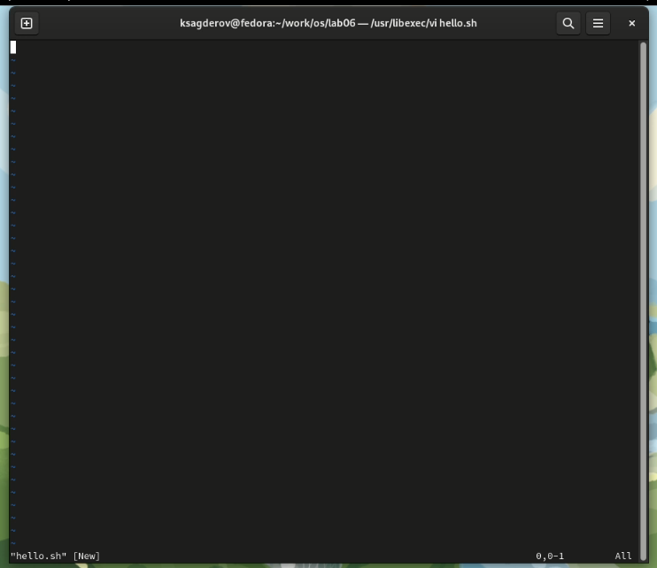

Файл hello.sh в текстовом редаеторе vi

## Процесс выполнения

4. Нажмем клавишу i и вводите следующий текст

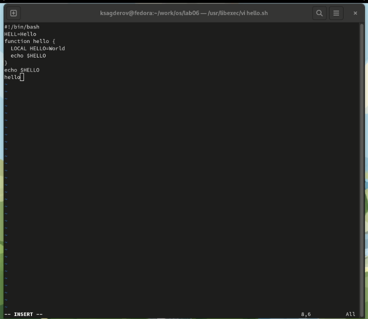

Написание текста в текстовом редакторе

## Процесс выполнения

5. Нажмем клавишу Esc для перехода в командный режим после завершения ввода текста.
6. Нажмем : для перехода в режим последней строки и внизу вашего экрана появится приглашение в виде двоеточия.
7. Нажмем w (записать) и q (выйти), а затем нажмите клавишу Enter для сохранения вашего текста и завершения работы

## Процесс выполнения

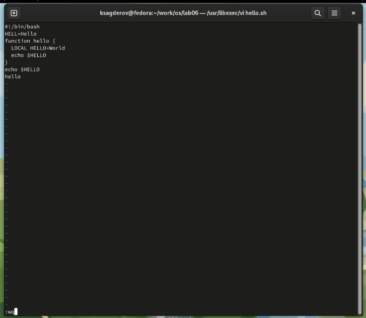

Выход из редактора и сохранение текста

## Процесс выполнения

8. Сделаем файл исполняемым

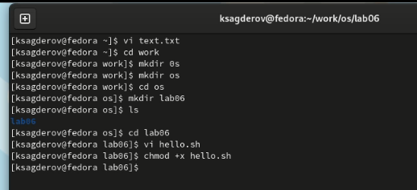

Сделаем файл исполняемым, команда chmod

## Процесс выполнения

Задание 2. Редактирование существующего файла 1. Вызовите vi на редактирование файла 2. Установите курсор в конец слова HELL второй строки. 3. Перейдите в режим вставки и замените на HELLO. Нажмите Esc для возврата в командный режим

## Процесс выполнения

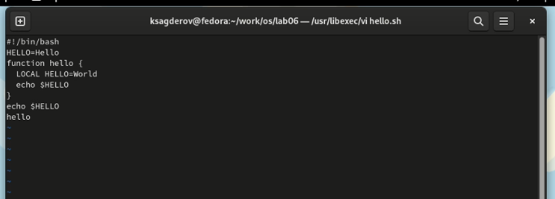

Работа с редактором vi

## Процесс выполнения

4. Установите курсор на четвертую строку и сотрите слово LOCAL.
5. Перейдите в режим вставки и наберите следующий текст: local, нажмите Esc для возврата в командный режим
6. Установите курсор на последней строке файла. Вставьте после неё строку, содержащую следующий текст: echo $HELLO

## Процесс выполнения

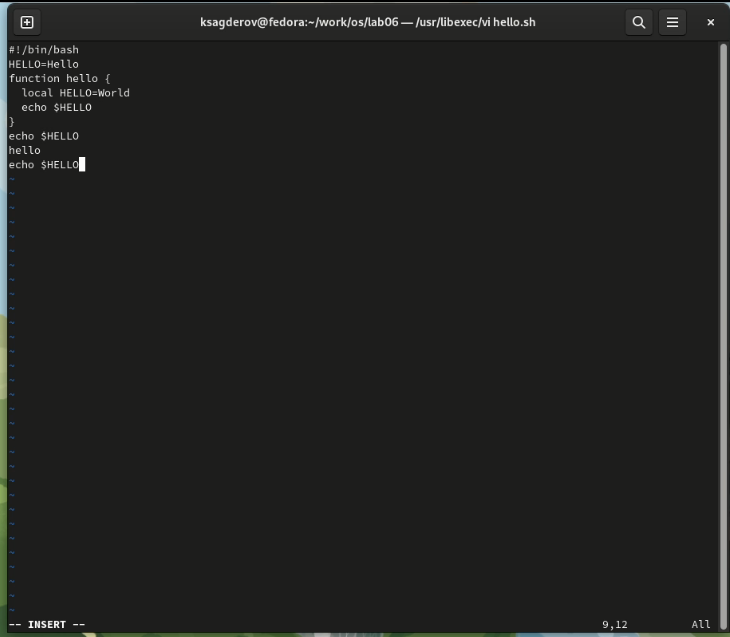

Изменение текста в редакторе vi

## Процесс выполнения

7. Нажмите Esc для перехода в командный режим.
8. Удалите последнюю строку

## Процесс выполнения

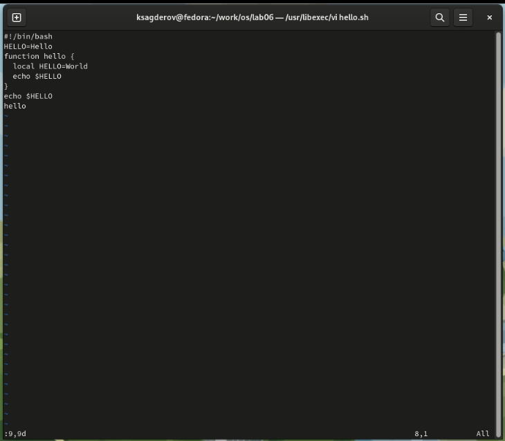

Удаление последней строки

## Процесс выполнения

9. Введите команду отмены изменений u для отмены последней команды

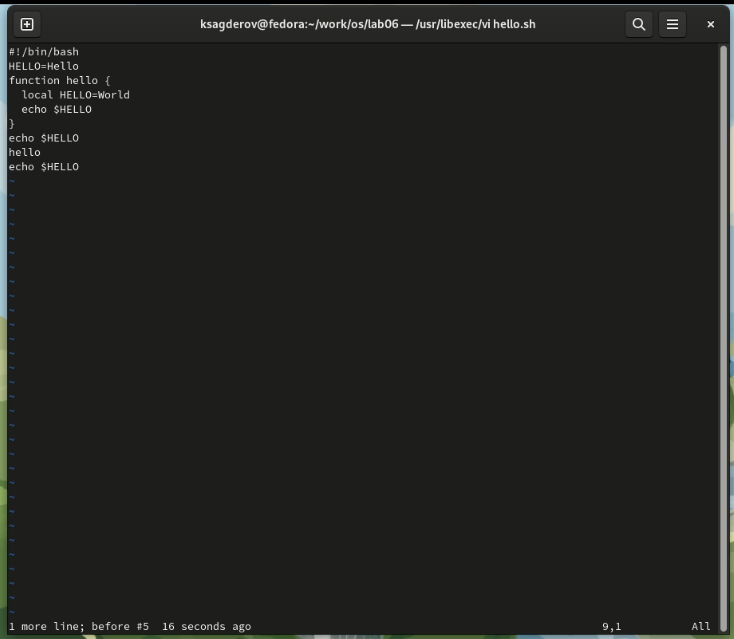

Команда отмены

## Процесс выполнения

10. Введите символ : для перехода в режим последней строки. Запишите произведённые изменения и выйдите из vi

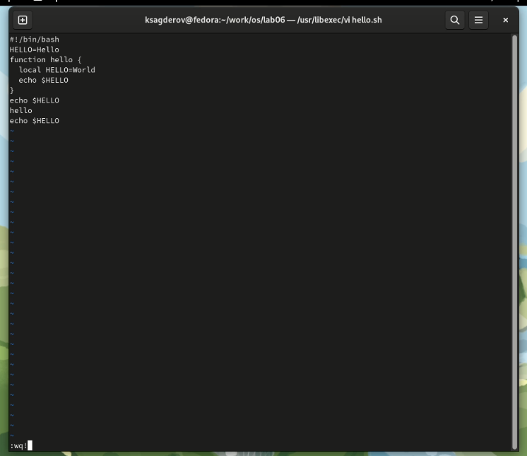

Выход из текстового редактора

## Выводы

В процессе выполнения лабораторной работы я ознакомился с текстовом редактором vi, получил практические навыки по работе с редактором, установленными по умолчанию практически во всех дистрибутивах.

# Спасибо за внимание!